# DATA MINING AND BUSINESS ANALYTICS WITH R

FdR

9 March 2015

This document intends to follow the book **DATA MINING AND BUSINESS ANALYTICS WITH R** from *Johannes Ledolter*. We are taking his work and adapting it to fit the dplyr + ggplot2 + tidyr set of libraries, as well as others when appropriate.

## Chapter 2. Processing the Information and Getting to Know Your Data

### 2.1 2006 Birth data.

We first load the library *nutshell* which contains our dataset, then load it and have a quick look at it.

```r
library(nutshell)
library(dplyr)
data(births2006.smpl)
str(births2006.smpl)
```

```
## 'data.frame':    427323 obs. of  13 variables:
##  $ DOB_MM   : int  9 2 2 10 7 3 5 4 10 4 ...
##  $ DOB_WK   : int  1 6 2 5 7 3 2 7 3 4 ...
##  $ MAGER    : int  25 28 18 21 25 28 33 31 18 24 ...
##  $ TBO_REC  : int  2 2 2 2 1 3 2 3 1 2 ...
##  $ WTGAIN   : int  NA 26 25 6 36 35 26 25 46 43 ...
##  $ SEX      : Factor w/ 2 levels "F","M": 1 2 1 2 2 2 2 1 1 2 ...
##  $ APGAR5   : int  NA 9 9 9 10 8 9 9 9 9 ...
##  $ DMEDUC   : Factor w/ 18 levels "1 year of college",..: 18 4 18 18 6 18 18 4 18 6 ...
##  $ UPREVIS  : int  10 10 14 22 15 18 10 19 15 13 ...
##  $ ESTGEST  : int  99 37 38 38 40 39 38 38 40 40 ...
##  $ DMETH_REC: Factor w/ 3 levels "C-section","Unknown",..: 3 3 3 3 3 3 1 1 1 3 ...
##  $ DPLURAL  : Factor w/ 5 levels "1 Single","2 Twin",..: 1 1 1 1 1 1 1 1 1 1 ...
##  $ DBWT     : int  3800 3625 3650 3045 3827 3090 3430 3204 3227 3459 ...
```

```r
tbl_df(births2006.smpl)
```

```
## Source: local data frame [427,323 x 13]
##
##    DOB_MM DOB_WK MAGER TBO_REC WTGAIN SEX APGAR5                 DMEDUC
## 1       9      1    25       2     NA   F     NA                   NULL
## 2       2      6    28       2     26   M      9     2 years of college
## 3       2      2    18       2     25   F      9                   NULL
## 4      10      5    21       2      6   M      9                   NULL
## 5       7      7    25       1     36   M     10 2 years of high school
## 6       3      3    28       3     35   M      8                   NULL
## 7       5      2    33       2     26   M      9                   NULL
## 8       4      7    31       3     25   F      9     2 years of college
## 9      10      3    18       1     46   F      9                   NULL
## 10      4      4    24       2     43   M      9 2 years of high school
## ..    ...    ...   ...     ...    ... ...    ...                    ...
## Variables not shown: UPREVIS (int), ESTGEST (int), DMETH_REC (fctr),
##   DPLURAL (fctr), DBWT (int)
```

There are 427,323 observations (ie. recorded births) in our dataset!

Our first graph is just about the frequency of birth in function of the day of the week.

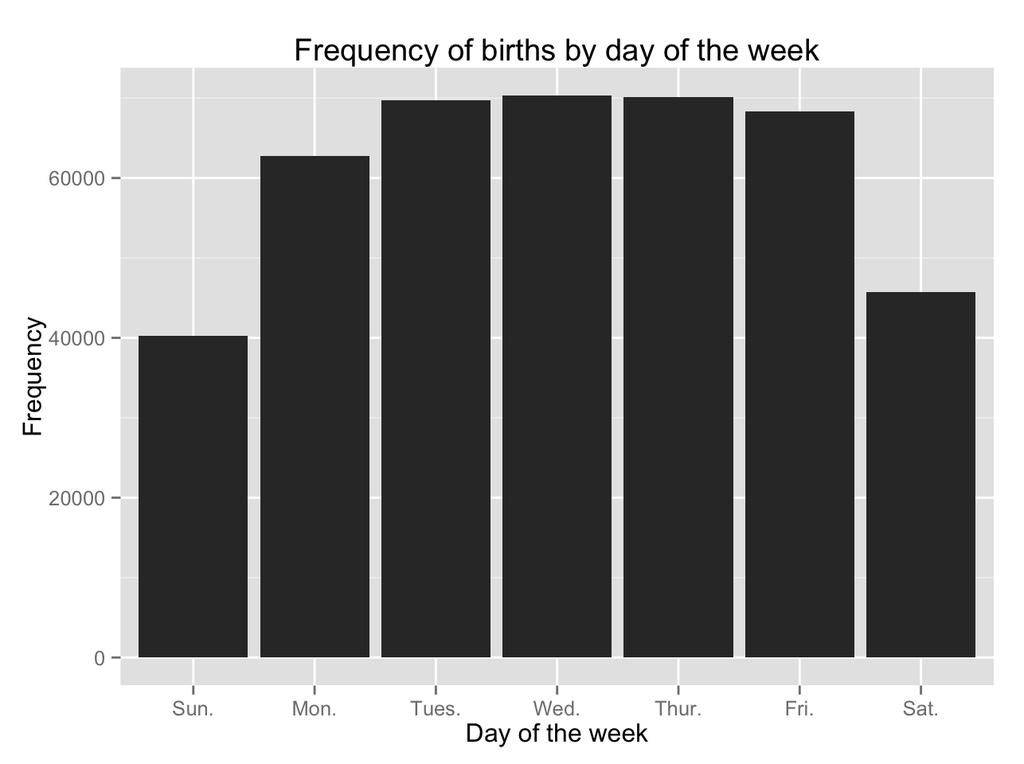

```r
library(ggplot2)
P1 <- ggplot(births2006.smpl, aes(x = DOB_WK)) +
  geom_bar() +
  scale_x_discrete(labels = c("Sun.", "Mon.", "Tues.", "Wed.", "Thur.", "Fri.", "Sat."),
                   limits = c(1:7)) +
  labs(title = "Frequency of births by day of the week",
       x = "Day of the week", y = "Frequency")
P1
```

They are clearly less birth on the weekend!

Or we can segregate by method of delivery and graph it that way.

```r
table(births2006.smpl$DOB_WK, births2006.smpl$DMETH_REC)
```

```
##
##     C-section Unknown Vaginal
##   1      8836      90   31348
##   2     20454     272   42031
##   3     22921     247   46607
##   4     23103     252   46935
##   5     22825     258   47081
##   6     23233     289   44858
##   7     10696     109   34878
```

We first re-order the levels in the `DMETH_REC` variable, so that the plot look pretty normal.

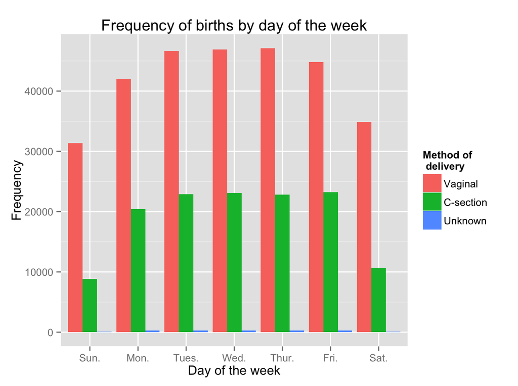

```r
births2006.smpl$DMETH_REC <- factor(births2006.smpl$DMETH_REC,
                                    levels = c("Vaginal", "C-section", "Unknown"))
P2 <- ggplot(births2006.smpl, aes(x = DOB_WK, fill = DMETH_REC)) +
  geom_bar(position = "dodge") +
  scale_x_discrete(labels = c("Sun.", "Mon.", "Tues.", "Wed.", "Thur.", "Fri.", "Sat."),
                   limits = c(1:7)) +
  labs(title = "Frequency of births by day of the week",
       x="Day of the week", y = "Frequency", fill = "Method of \n delivery")
P2
```

On the next graph, we are using `facet_grid()` to make 2 graphs. There is a bit of plumbing to do first tough.

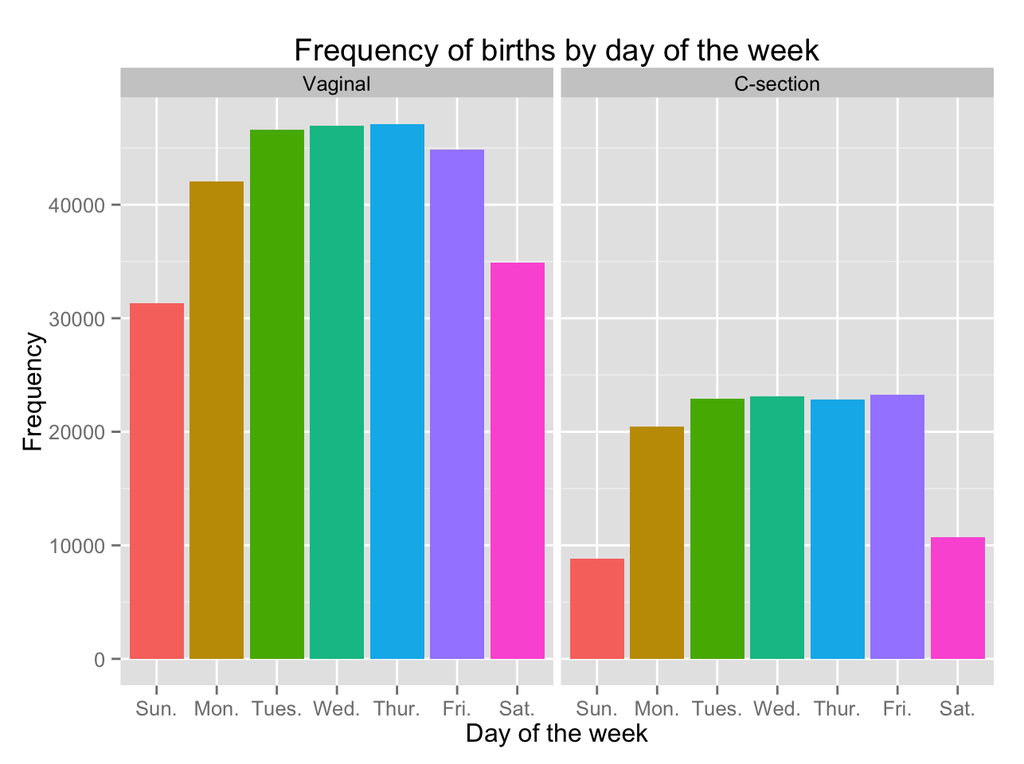

```r
data <- as.data.frame(table(births2006.smpl$DOB_WK, births2006.smpl$DMETH_REC))
data3 <- filter(data, Var2 != "Unknown")
P3 <- ggplot(data3, aes(x=Var1, y=Freq, fill = Var1)) +
  geom_bar(stat="identity") + facet_grid(.~ Var2) +
  guides(fill=F) +
  scale_x_discrete(labels = c("Sun.", "Mon.", "Tues.", "Wed.", "Thur.", "Fri.", "Sat.")) +
  labs(title = "Frequency of births by day of the week",
       x="Day of the week", y = "Frequency")
P3
```

I think it might be slightly more interesting to actually compare the percentage of birth by vaginal or C-section on each day of the week.

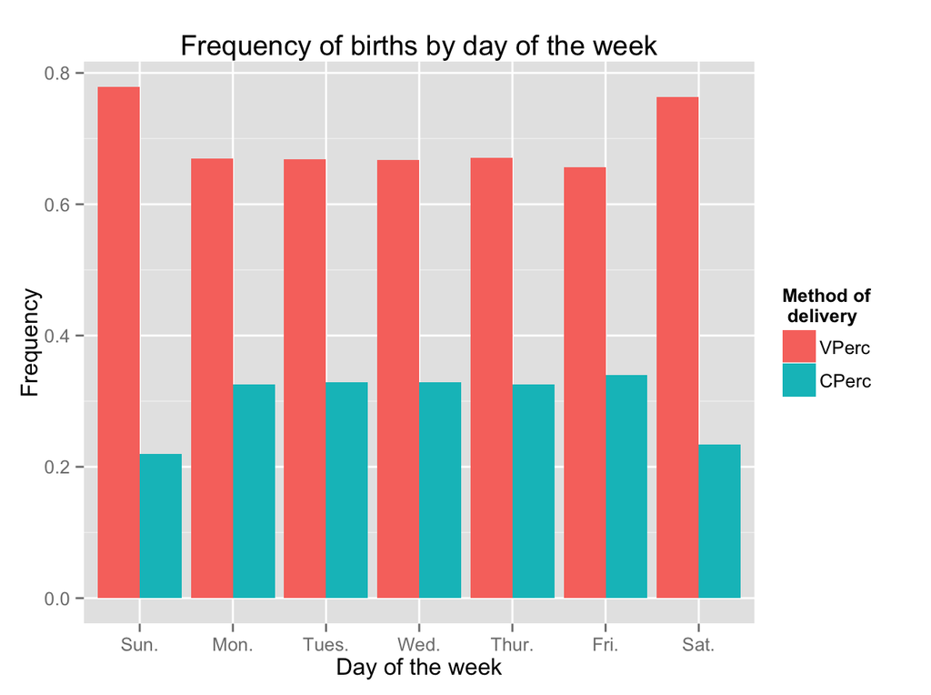

```r
library(tidyr)
data4 <- data %>% spread(Var2, Freq)
data4 <- data4 %>% mutate(Total = Vaginal + data4[,3] + Unknown) %>%
  mutate(VPerc = Vaginal / Total, CPerc = data4[,3] / Total) %>%
  select(1, 6:7) %>%
  gather("Method", "Percentage", VPerc:CPerc)
P4 <- ggplot(data4, aes(x = Var1, y = Percentage, fill = Method)) +
  geom_bar(stat = "identity", position = "dodge") +
  scale_x_discrete(labels = c("Sun.", "Mon.", "Tues.", "Wed.", "Thur.", "Fri.", "Sat.")) +
  labs(title = "Frequency of births by day of the week",
       x="Day of the week", y = "Frequency", fill = "Method of \n delivery")
P4
```

Finally I have always wondered about this.

```r
data5 <- data %>% spread(Var2, Freq)
```